# Sequential Statistical Methods for Reliable ML — Sulam

Sequential Statistical Methods

for Reliable Machine Learning

Jeremias Sulam

Trustworthy AI Workshop · Simons Institute · October 2026

[figure not shown]

[figure not shown]

## Why audit deployed models

Sepsis alerts

Epic’s sepsis model at Michigan Medicine: AUC 0.63 against the 0.76–0.83 reported, 67% of cases missed.

COVID-19

Sepsis alerts up 43% across 24 hospitals in four US health systems — with 35% fewer patients in the hospital (electives cancelled).

GPT-4

GPT-4 identifying prime numbers: 84% accurate in March 2023, 51% in June.

Checking a model once, before deployment, is not enough.

[Wong et al, 2021a,b][Chen, Zaharia & Zou, 2023]

## Auditing a model

Each prediction gives an audit score $Z_t \in [-1,1]$, e.g. $Z_t = f(X_t) - Y_t$, i.i.d. from some $P$.

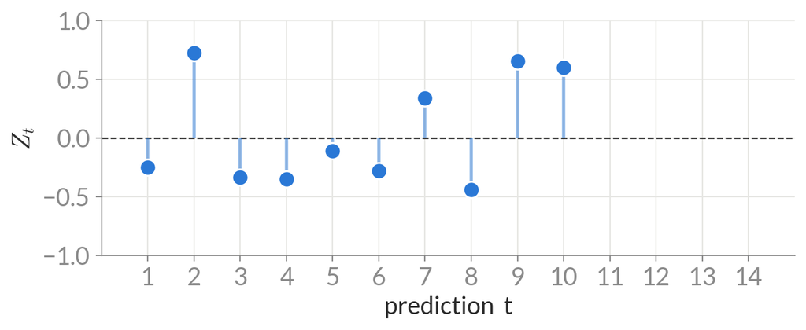

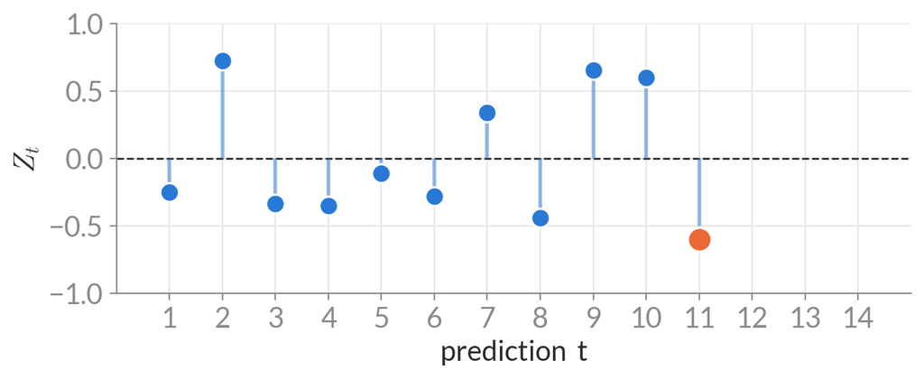

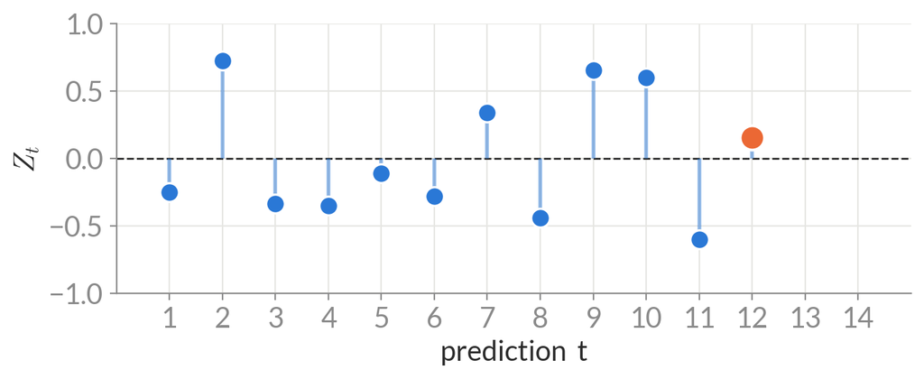

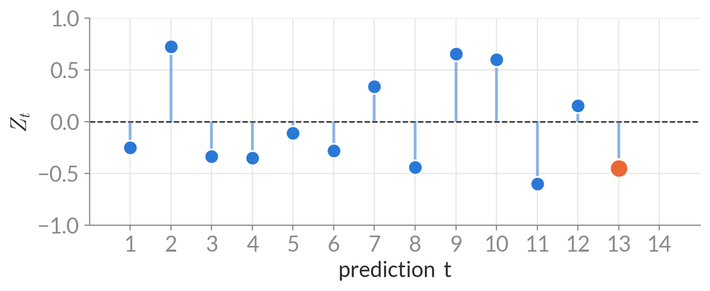

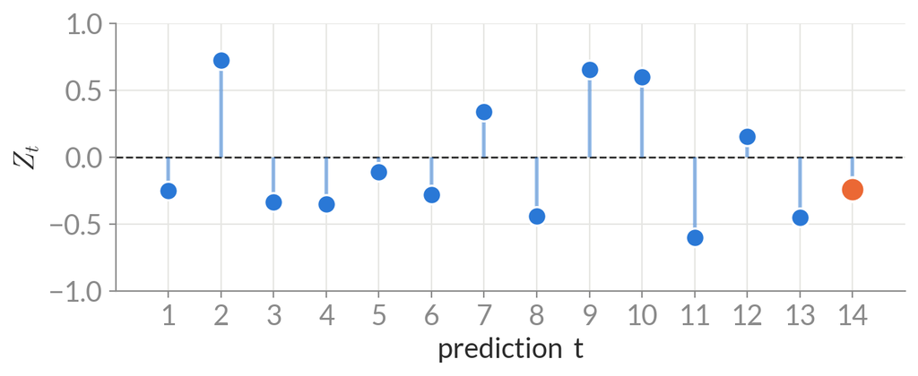

Is $\E_P[Z] = 0$? That is, does the model work as intended?

We need a **sequential** test $\phi_t \in \{0,1\}$ (1: reject, flag the model):
$$\sup_{P:\,\E_P[Z]=0}\ P\big(\exists\, t:\ \phi_t = 1\big)\ \le\ \alpha$$

[Chugg et al, 2023][Dai et al, 2025]

## Testing by betting

Is the coin fair? Heads $Z_t = +1$, tails $Z_t = -1$. Start at $W_0 = 1$, bet $\lambda_t$:

$$W_t = W_{t-1}\,(1 + \lambda_t Z_t), \qquad \lambda_t \text{ chosen before seeing } Z_t$$

| t | my bet $\lambda_t$ | flip | $W_t$ |
| --- | --- | --- | --- |
| 1 | 0 (I know nothing) | H | 1.00 |
| 2 | 0.2 (lean heads) | H | 1.20 |
| 3 | 0.3 (more) | T | 0.84 |
| 4 | 0.15 (back off) | H | 0.97 |
| 5 | 0.2 | H | 1.16 |

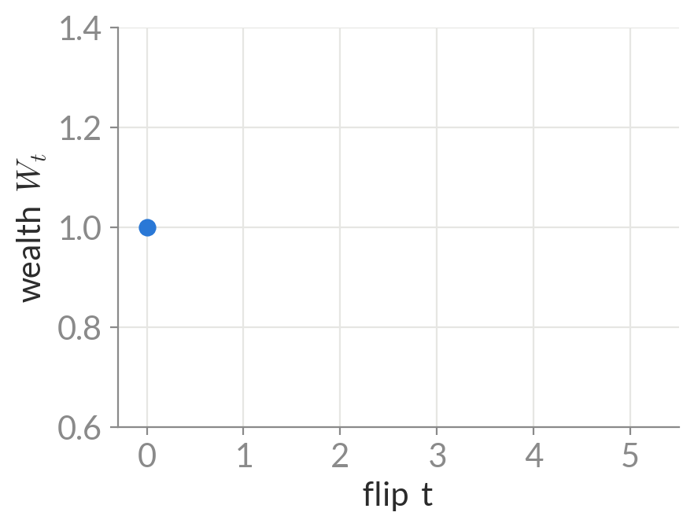

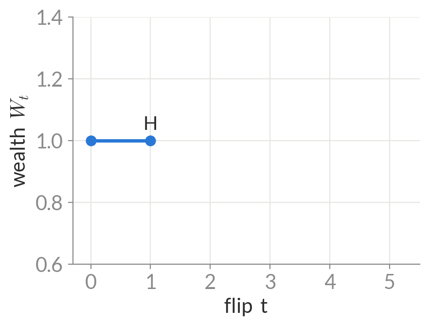

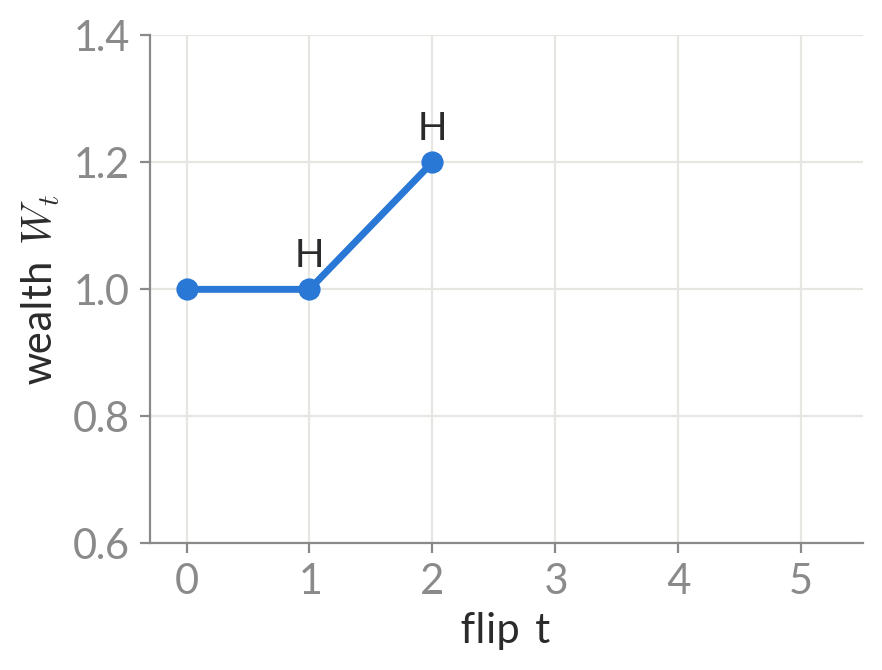

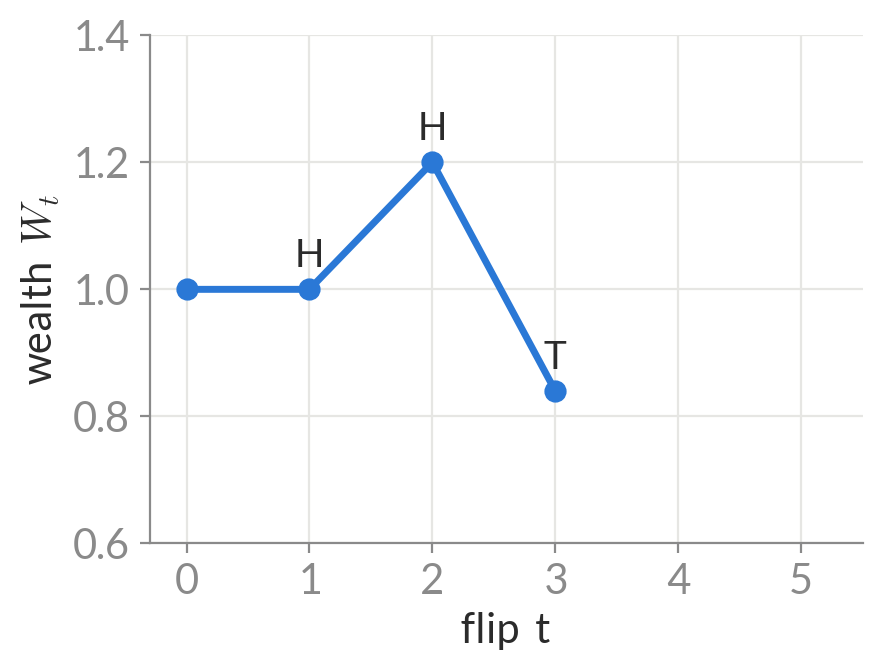

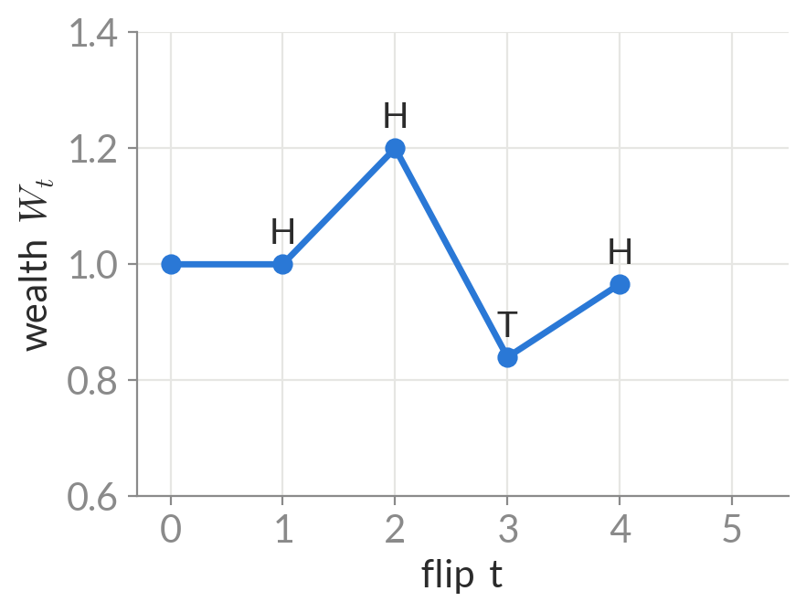

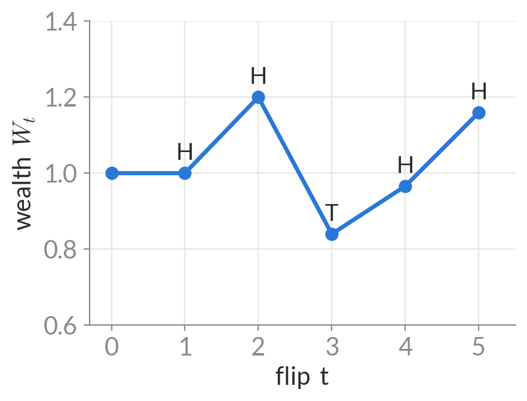

[Shafer, 2021][Waudby-Smith & Ramdas, 2024]

## Testing by betting

If the coin is fair, no strategy makes money on average:

$$\E[W_t \mid Z_1,\dots,Z_{t-1}] = W_{t-1}$$

So (Ville) $\quad P_{H_0}\big(\exists\, t:\ W_t \ge 1/\alpha\big) \le \alpha$.

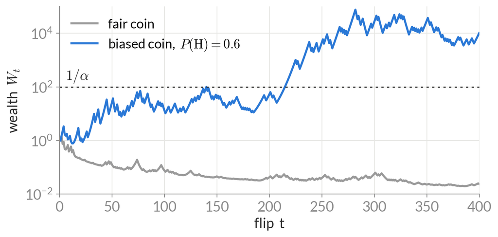

Reject when $W_t \ge 1/\alpha$. Same for any bounded $Z_t$ with $H_0:\ \E[Z]=0$.

[Ville, 1939]

## Stopping time and power

Stopping time $\ \tau = \min\{t:\ W_t \ge 1/\alpha\}$. $\quad$ Powerful test $\iff$ small $\E[\tau]$.

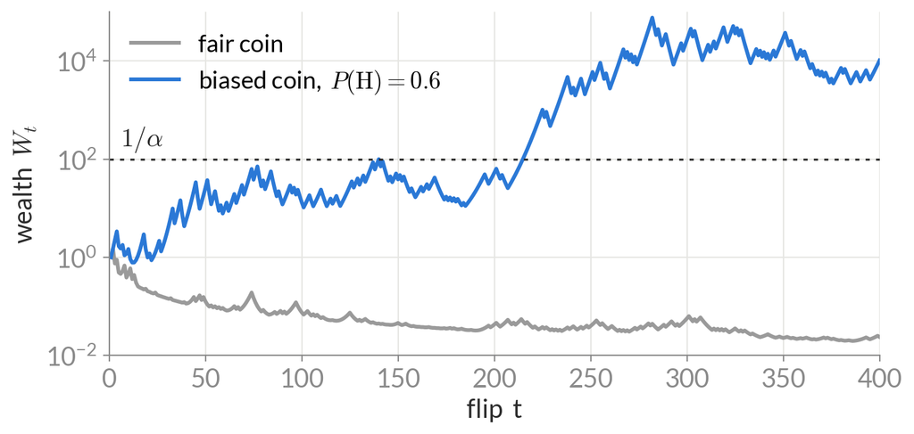

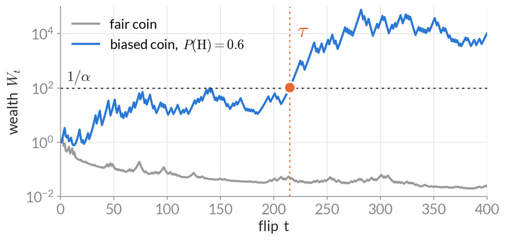

How to choose $\lambda_t$? ONS, universal portfolios, mixtures, aGRAPA, …

With ONS, $\ \ln W_t \gtrsim \Delta^2 t/4$ for $\Delta = \E[Z]$, so that $\ \E[\tau] = \mathcal O\big(\tfrac{1}{\Delta^2}\ln\tfrac{1}{\alpha\Delta^2}\big)$.

[Cutkosky & Orabona, 2018][Chugg et al, 2023][Waudby-Smith & Ramdas, 2024]

## Two questions

Q1: How can we quickly test if a model deployed across many locations or groups is not working as expected?

global hypothesis testing

Q2: How do we quantify uncertainty in predictors over different groups making minimal assumptions and with potential shifts?

online conformal prediction

In both cases we want guarantees that

- hold at any time, since we check continuously,
- hold for every group, not just on average,
- need no tuning, since we can’t anticipate the shift.

Q1: How can we quickly test if a model deployed across many locations or groups is not working as expected?

global hypothesis testing

Q2: How do we quantify uncertainty in predictors over different groups making minimal assumptions and with potential shifts?

online conformal prediction

## Groups

A group is a function $\ c:\mathcal X \to [0,1]$: how much $x$ belongs to it.

imaging modality

- chest X-ray
- lung CT
- mammogram
- retinal OCT

demographics

- female, 50+
- male, under 30
- on Medicare

soft membership

- $P(\text{smoker} \mid x)$
- $P(\text{Medicaid} \mid x)$

$c(X_t) = \big(\underset{\text{chest X-ray}}{1},\ \underset{\text{lung CT}}{0},\ \underset{\text{female, 50+}}{1},\ \underset{P(\text{smoker}\mid x)}{0.5},\ \dots\big)$ Groups may overlap.

## Auditing every group

At each time $t$ we observe one audit score per group, $Z_{1,t},\dots,Z_{k,t}$.

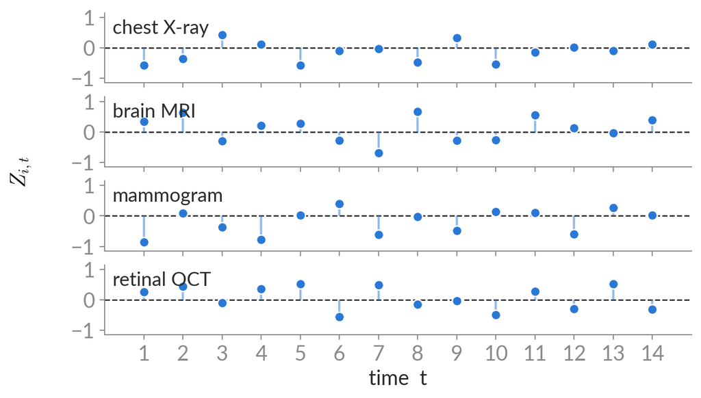

$$H_0:\ \E[Z_i] = 0\ \text{ for all } i \qquad\text{vs.}\qquad H_1:\ \E[Z_i] \ne 0\ \text{ for some } i$$

## Bonferroni

Track the max-wealth over all groups: reject when $\ \tfrac{1}{\cR{k}}\max_{i} W_{i,t} \ge \tfrac1\alpha$

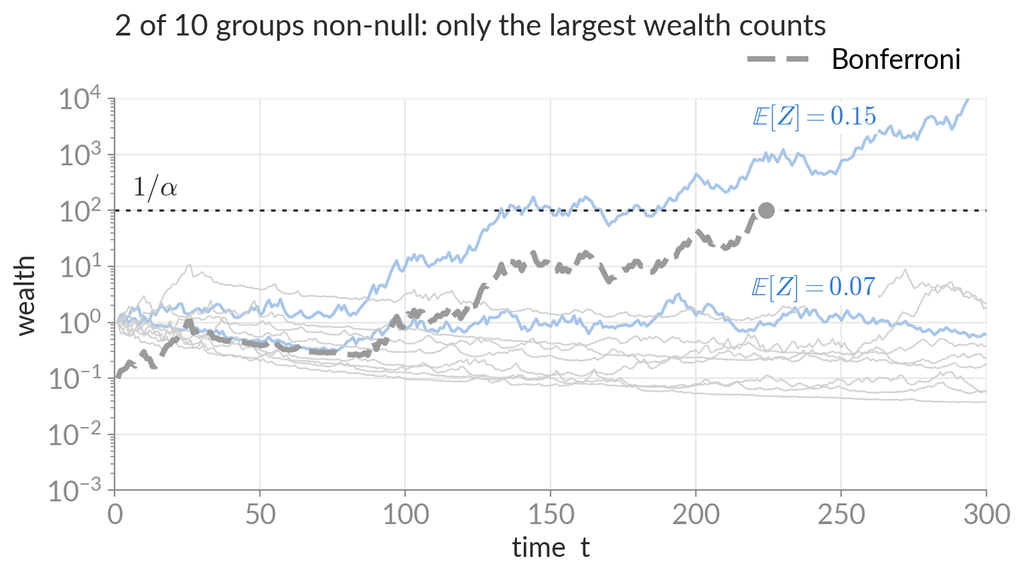

Stopping time: $\ \E[\tau] = \mathcal O\big(\tfrac{1}{\Delta_{\max}^2}\ln\tfrac{\cR{k}}{\alpha\,\Delta_{\max}^2}\big)$

- threshold $\cR{k}/\alpha$: $+\ln \cR{k}$ in time, however many groups are non-null
- only the largest wealth counts

[Chugg et al, 2023]

## Merging evidence

Product
$$W^{\text{prod}}_t = \prod_{i=1}^k W_{i,t}$$
independent across groups

Average
$$W^{\text{ave}}_t = \frac1k\sum_{i=1}^k W_{i,t}$$
any dependence across groups

Streams are i.i.d. in time.

Both are nonnegative martingales under $H_0$, so both reject at $1/\alpha$.

How fast does each one stop?

[Vovk & Wang, 2021][Ramdas & Wang, 2025]

## Sparse and dense alternatives

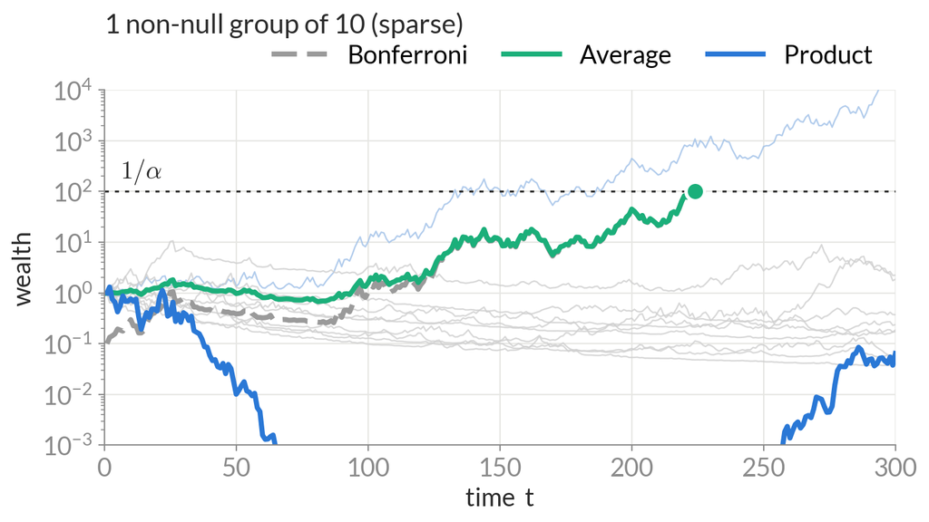

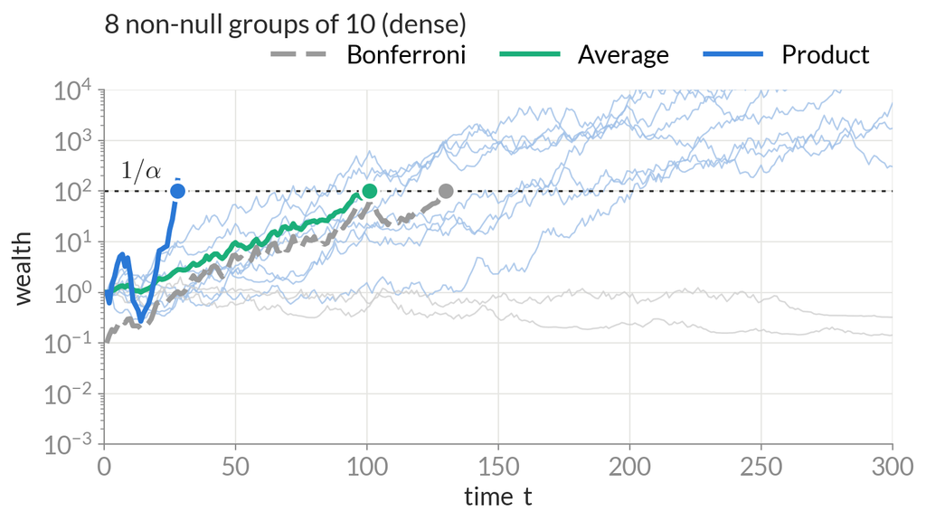

## Expected stopping times

|  | sparse (one group) | dense (all groups) |
| --- | --- | --- |
| Bonferroni | $\ln\frac1\alpha + \ln k$ | $\ln\frac1\alpha + \ln k$ |
| Product | $\ln\frac1\alpha + {\color{cc0000}k\ln k}$ | ${\color{1baf7a}\frac1k}\ln\frac1\alpha$ |
| Average | $\ln\frac1\alpha + \ln k$ | $\ln\frac1\alpha$ |
| **Balanced** | $\ln\frac1\alpha + \ln k$ | ${\color{1baf7a}\frac1k}\ln\frac1\alpha$ |

leading terms for large $k$, small $\alpha$, fixed signal

$$W^{\text{bal}}_t = \tfrac12\, W^{\text{ave}}_t + \tfrac12\, W^{\text{prod}}_t
\quad\Longrightarrow\quad
\E[\tau] \le \min\{T_{\text{prod}},\, T_{\text{bonf}}\}$$
under independence of streams

Note: Bonferroni also provides strong FWER control; merging does not.

[Bharti, Pal, S., 2026]

## Zero-shot medical imaging

ConceptCLIP (medical vision–language model), zero-shot, $Z = f(X) - Y$, $k = 10$ groups: brain CT, brain MRI, chest X-ray, mammogram, retinal OCT, colon endoscopy, … Eight are biased; after debiasing, only colon endoscopy.

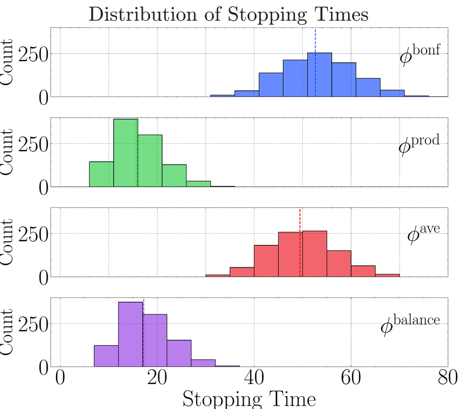

8 of 10 non-null: product and balanced first

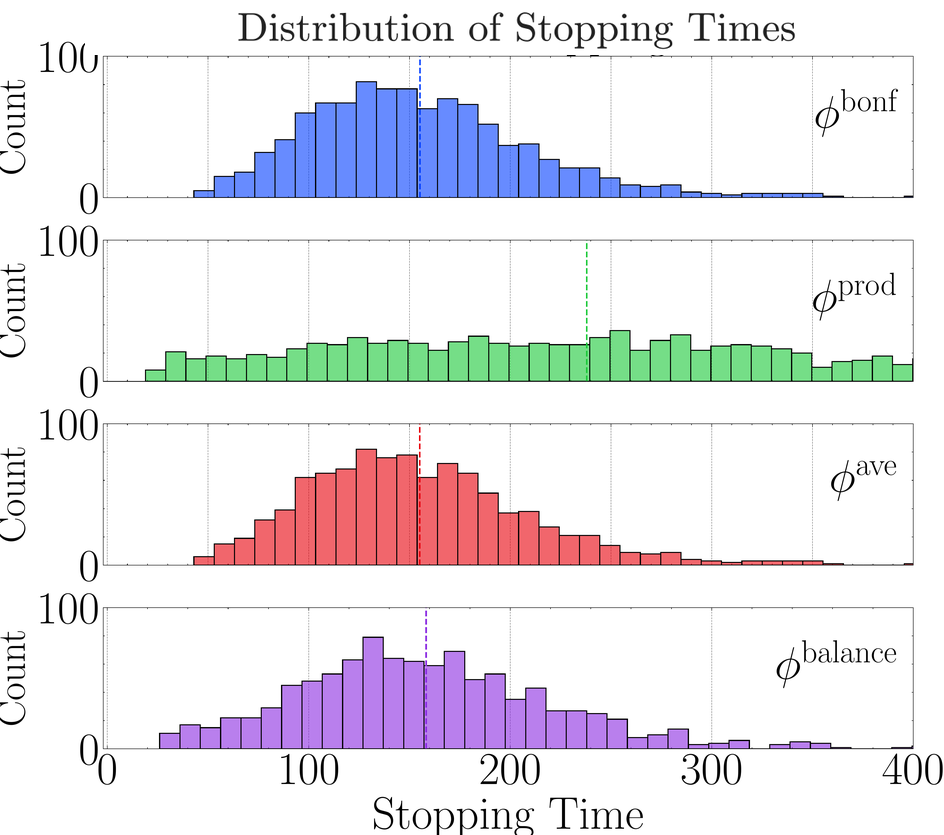

1 of 10 non-null: Bonferroni and average first

[Nie et al, 2025][Kim et al, 2019]

Q1: How can we quickly test if a model deployed across many locations or groups is not working as expected?

global hypothesis testing

- One betting test per group.
- Merge the wealth: $\tfrac12$ average $+\ \tfrac12$ product.
- Stops nearly as fast as the best rule for either sparse or dense regimes, without knowing which.

Q1: How can we quickly test if a model deployed across many locations or groups is not working as expected?

global hypothesis testing

Q2: How do we quantify uncertainty in predictors over different groups making minimal assumptions and with potential shifts?

online conformal prediction

## Online prediction intervals

Patient $t$ arrives at the emergency department. We predict the length of stay $\hat Y_t$, post $\mathcal I_t = [\hat Y_t - \tau_t,\ \hat Y_t + \tau_t]$, then observe $Y_t$.

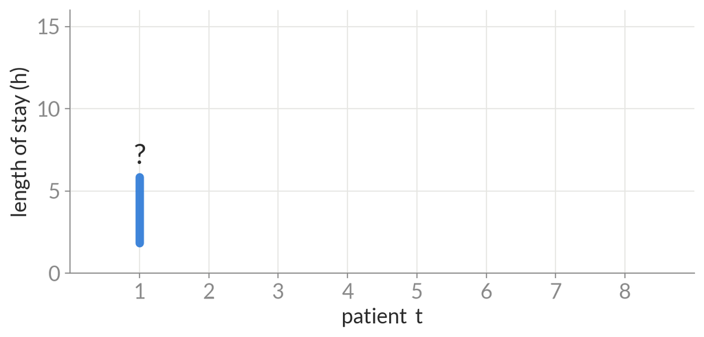

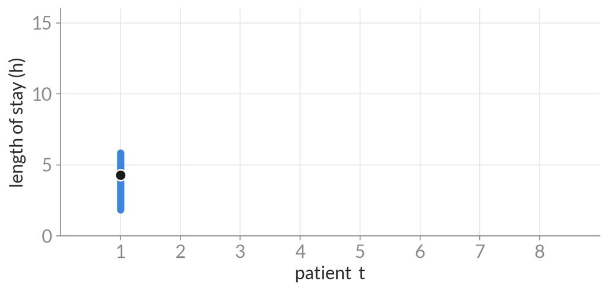

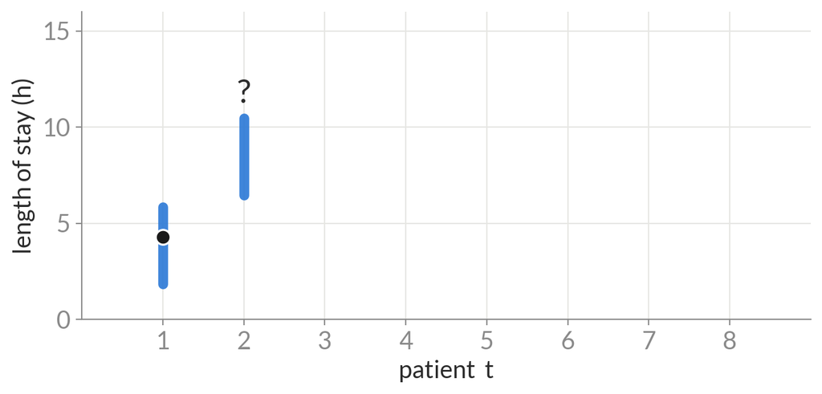

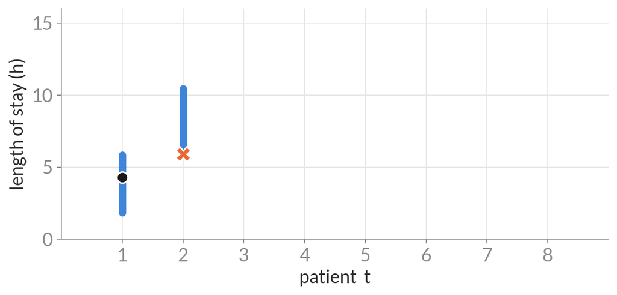

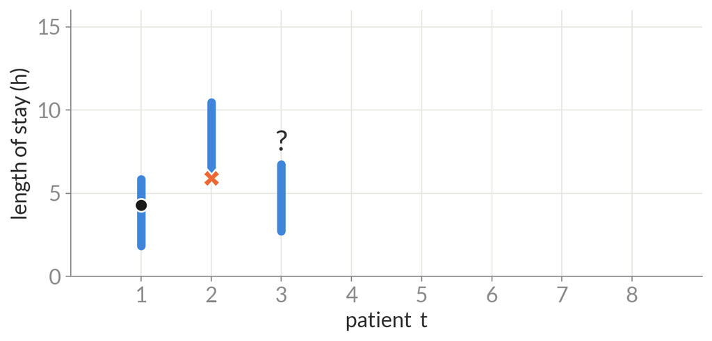

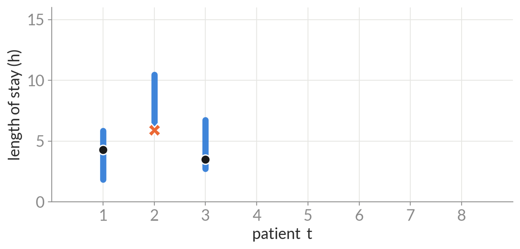

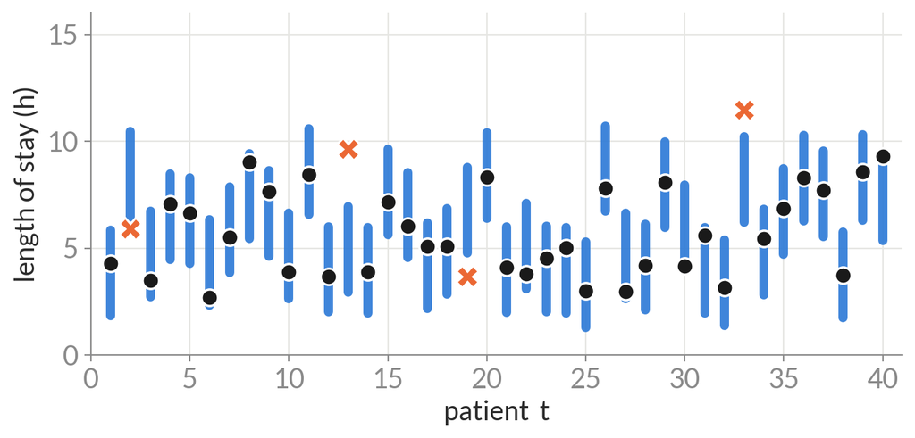

Covered when $\ S_t := |Y_t - \hat Y_t| \le \tau_t$.

**Goal:** for **any** sequence $(X_t,Y_t)$, $\qquad \tfrac1T\textstyle\sum_{t\le T} \mathbf 1\{S_t \le \tau_t\}\ \longrightarrow\ 1-\alpha$

No distributional assumptions: any shift, even adversarial.

[Gibbs & Candès, 2021]

## Tracking the quantile loss online

pinball loss of the radius: $\quad \ell_t(\tau) = \max\{(1-\alpha)(S_t-\tau),\ \alpha(\tau - S_t)\}$

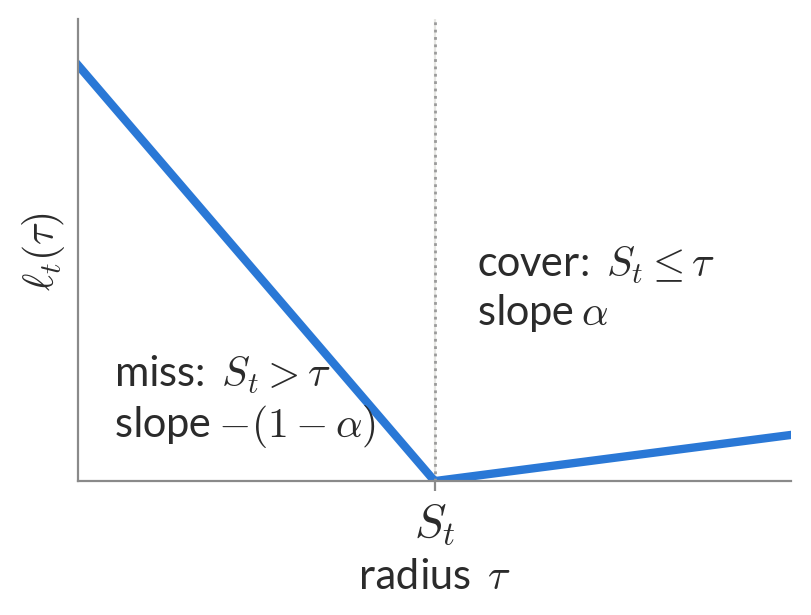

subgradient at $\tau_t$:
$$g_t = \mathbf 1\{S_t \le \tau_t\} - (1-\alpha)$$

ACI subgradient descent:
$$\tau_{t+1} = \tau_t - \eta\, g_t$$
a miss widens by $\eta(1-\alpha)$, a cover shrinks by $\eta\alpha$

The subgradients add up to the coverage error:
$$\MisCov_T = \Big|\tfrac1T\textstyle\sum_{t} \mathbf 1\{S_t\le\tau_t\} - (1-\alpha)\Big| = \tfrac{1}{T}\big|\textstyle\sum_t g_t\big|$$

$\eta$ needs to be set in advance and is hard to tune.

[Gibbs & Candès, 2021]

## Coverage through betting

Each sample is a coin flip: *miss* ($Y_t\notin\mathcal I_t$) or *cover* ($Y_t\in\mathcal I_t$). We want misses at rate $\alpha$.

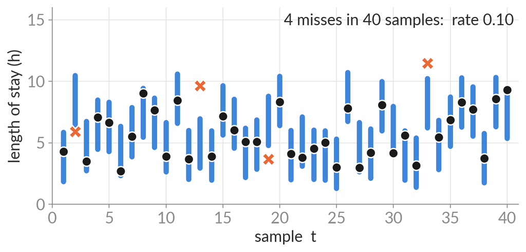

The coin: $\ Z_t = \mathbf 1\{\text{miss}_t\} - \alpha \in \{-\alpha,\ 1-\alpha\}$. Then, the wealth:
$$W_t = W_{t-1}\,(1 + \lambda_t Z_t)$$

If $\ \varepsilon_T = \tfrac1T\sum_{t\le T} \mathbf 1\{\text{miss}_t\} - \alpha = 0$, no bettor makes money. Otherwise, the bettor makes money.

[Shafer & Vovk, 2001][Vovk, Takemura & Shafer, 2005]